# Tier Classification with Random Forests and KNN Machine Learning

2024-02-23

```r
library(tidyverse)
library(gridExtra)
library(caret)
library(fmsb)
create_beautiful_radarchart <- function(data, color = "#00AFBB",
                                        vlabels = colnames(data), vlcex = 0.7,
                                        caxislabels = NULL, title = NULL, ...){
  radarchart(
    data, axistype = 1,
    # Customize the polygon
    pcol = color, pfcol = scales::alpha(color, 0.5), plwd = 2, plty = 1,
    # Customize the grid
    cglcol = "grey", cglty = 1, cglwd = 0.8,
    # Customize the axis
    axislabcol = "grey",
    # Variable labels
    vlcex = vlcex, vlabels = vlabels,
    caxislabels = caxislabels, title = title, ...
  )
}
```

This file contains an exploration of the classification analysis for Pick/Ban Rate, Win Rate, and KDA, as attempts to predict Tier.

```r
leaguedf <- read_csv('../data_sets/S13LeagueOfLegendsData.csv', col_types=cols()) %>%
  select(c(5, 8, 10, 11, 12)) %>%
  rename(winr = "Win %", pick = 'Pick %', ban = 'Ban %') %>%
  mutate(pbr = pick + ban) %>%
  select(-c(3,4))

head(leaguedf, 5)
```

```
## # A tibble: 5 × 4
##   Tier   winr   KDA    pbr
##   <chr> <dbl> <dbl>  <dbl>
## 1 S     0.477  1.77 0.186
## 2 S     0.495  2.58 0.0754
## 3 S     0.484  2.37 0.211
## 4 C     0.459  2    0.156
## 5 A     0.516  2.26 0.0654
```

#### Key for Reference

- Tier: Tier of champion
- winr: winrate of champion
- KDA: Kill/Death/Assist Ratio, $\frac{\texts{kills} + \text{assists}}{\text{deaths}}$
- pbr: Pick Ban Rate, Pick rate + Ban rate

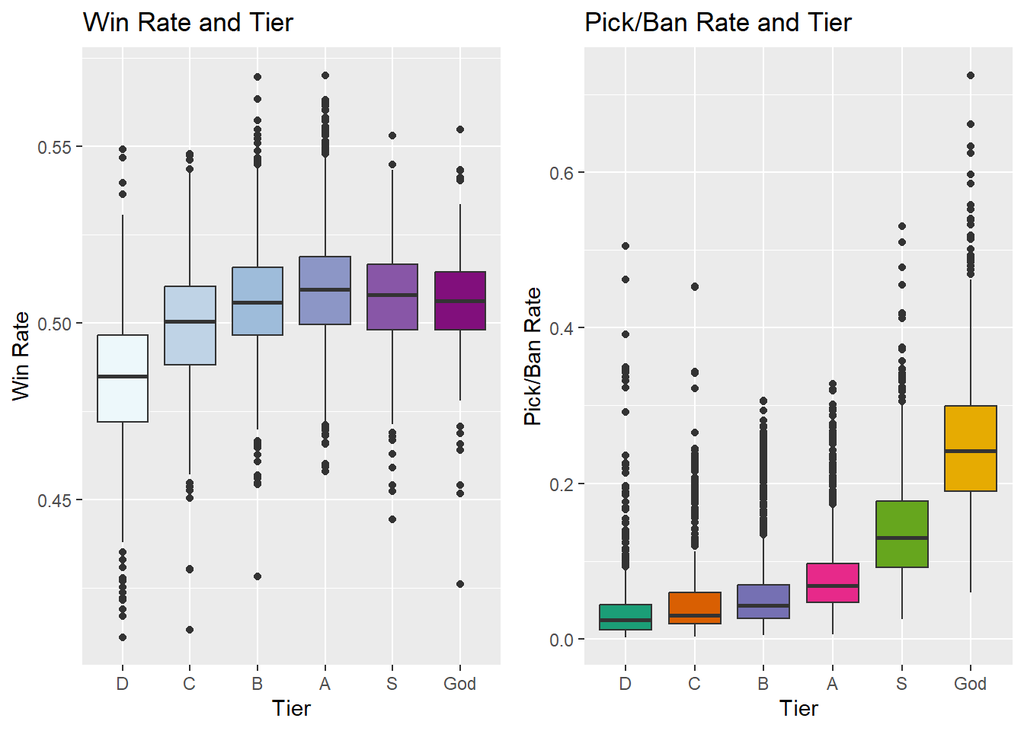

```r
leaguedf$Tier <- factor(leaguedf$Tier, levels=c('D', 'C', 'B', 'A', 'S', 'God'), ordered=TRUE)
plot1 <- ggplot(data=leaguedf) +
  geom_boxplot(mapping = aes(x = Tier, y=winr, fill=Tier)) +
  ggtitle('Win Rate and Tier') +
  ylab('Win Rate') +
  theme(legend.position='none') +
  scale_fill_brewer(palette="BuPu")

plot2 <- ggplot(data = leaguedf) +
  geom_boxplot(mapping = aes(x= Tier, y=pbr, fill=Tier)) +
  ggtitle('Pick/Ban Rate and Tier') +
  ylab('Pick/Ban Rate') +
  theme(legend.position='none') +
  scale_fill_brewer(palette="Dark2")


grid.arrange(plot1, plot2, ncol=2)
```

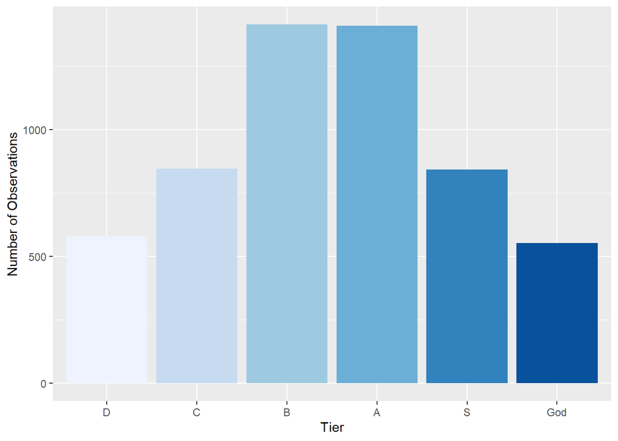

```r
ggplot(data=leaguedf) +
  geom_bar(mapping=aes(x=Tier, fill=Tier)) +
  scale_fill_brewer('viridis') +
  theme(legend.position = 'none') + ylab("Number of Observations")
```

[figure not shown]

```r
tier_stats <- leaguedf %>%
  group_by(Tier) %>%
  summarize(KDA = median(KDA), pbr = median(pbr), wr=median(winr))
tier_stats$Tier <-  factor(tier_stats$Tier, levels=c('D', 'C', 'B', 'A', 'S', 'God'), ordered=TRUE)
tier_stats <- as_tibble(tier_stats) %>% column_to_rownames(var = "Tier")
  # statistics wanted by tier, and change row name to tier

max_min <- data.frame(KDA = c(0, 5), pbr=c(0,1), wr=c(0,1)) #Formatting data for radar chart
rownames(max_min) <- c("Max", "Min")

radar_frame <- rbind(max_min, tier_stats) #final frame for radar chart

#The next two lines split the area for the radar charts
op <- par(mar = c(1.5,1.5,1.5,1.5))
#Split into 6 pieces
par(mfrow = c(2,3))

#Color for each tier
colors = c("#D95F45", "#D9B245", "#62D945", "#45D9AA", "#45A6D9", "#7145D9")

#Title for each chart
titles = c("A", "B", "C", "D", "S", "God")

#make them
for (i in 1:6) {
  create_beautiful_radarchart(data = radar_frame[c(1,2, i+2), ],
                              color = colors[i], title = titles[i]
                              )
} #TODO: FIgure out why its wrong
```

```r
par(op)
```

p.s. I think spider plot is cooler name than radar chart.

## Thoughts

- For higher tiers, such as God, S, and A, it seems that pick ban rate significantly rises.
- For lower tiers, such as D and C, the win rate significantly drops.
- Alone, each of them would likely only do so well to analyze the tiers, but together they seem to be better.
- The number of observations is fairly symmetric with respect to the middle (A/B)

## Moving Forwards

```r
set.seed(27)

# Split the data into test/train. We want 75% for training, and 25% for testing.

inTrain <- createDataPartition(y=leaguedf$Tier, p=0.75, list=FALSE)

leagueTrain <- leaguedf[ inTrain, ]
leagueTest <- leaguedf[ -inTrain, ]

#Verify we did it correct, 0.75*5637 is approx 4225
nrow(leagueTrain)
```

```
## [1] 4229
```

```r
#Now we start the creation of the models, we chose K-nearest-neighbors, random-forest, and .... stuff
#NOTE PLEASE TRAIN MODELS IN SEPERATE FILE, SAVE AND IMPORT HERE. TRAINING HERE MAKES KNITTING THE RMD FILE TAKE A LONG TIME.
#Consider just doing 1 model and justifying?
#Ranger should work with high dimensional data, I don't think 3 counts lol.

rf_fit <- train(as.factor(Tier) ~ .,
                data = leagueTrain,
                method="ranger")
rf_fit
```

```
## Random Forest
##
## 4229 samples
##    3 predictor
##    6 classes: 'D', 'C', 'B', 'A', 'S', 'God'
##
## No pre-processing
## Resampling: Bootstrapped (25 reps)
## Summary of sample sizes: 4229, 4229, 4229, 4229, 4229, 4229, ...
## Resampling results across tuning parameters:
##
##   mtry  splitrule   Accuracy   Kappa
##   2     gini        0.5249046  0.4112256
##   2     extratrees  0.5329442  0.4206827
##   3     gini        0.5203712  0.4058132
##   3     extratrees  0.5300368  0.4175144
##
## Tuning parameter 'min.node.size' was held constant at a value of 1
## Accuracy was used to select the optimal model using the largest value.
## The final values used for the model were mtry = 2, splitrule = extratrees
##  and min.node.size = 1.
```

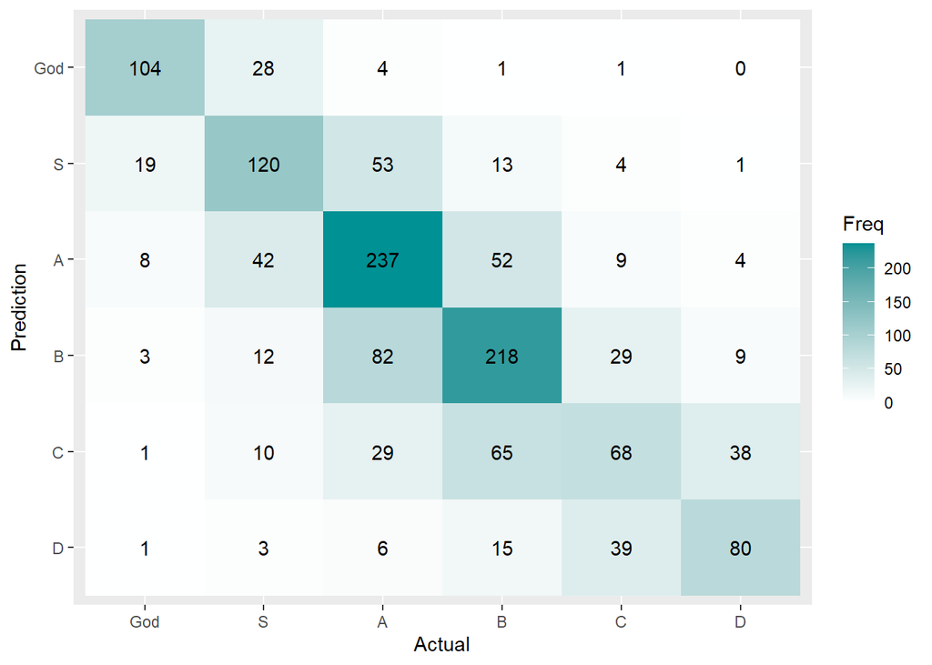

```r
rf_pred <- predict(rf_fit, leagueTest)

cm <- confusionMatrix(rf_pred, as.factor(leagueTest$Tier), dnn = c("Prediction", "Actual"))
plt <- as.data.frame(cm$table)
plt$Prediction <- factor(plt$Prediction, levels=rev(levels(plt$Prediction)))

ggplot(plt, aes(Prediction,Actual, fill=Freq)) +
        geom_tile() + geom_text(aes(label=Freq)) +
        scale_fill_gradient(low="white", high="#009194") +
        labs(x = "Actual",y = "Prediction") +
        scale_y_discrete(labels=c('D', 'C', 'B', 'A', 'S', 'God')) +
        scale_x_discrete(labels=c('God', 'S', 'A', 'B', 'C', 'D'))
```

```r
Mode <- function(x) {
  ux <- unique(x)
  ux[which.max(tabulate(match(x, ux)))]
}

Boundarydf = expand.grid(winr = seq(0.4, 0.6, length.out=100), pbr = seq(0, 1, length.out=100), KDA = seq(1, 5, length.out=100))
Boundarydf$Tier <- predict(rf_fit, Boundarydf)
Boundarydf <- Boundarydf %>%
  group_by(winr, pbr) %>%
  summarize(Tier = Mode(Tier)) %>%
  ungroup()
```

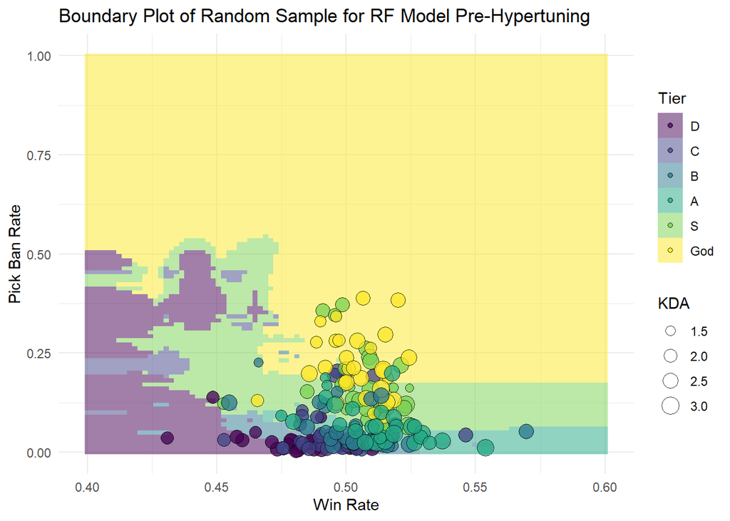

```r
randomentries <- tibble(winr = c(), pbr = c(), Tier=c())
for (tier in unique(Boundarydf$Tier)) {
  randomentries <- bind_rows(randomentries, sample_n(filter(leaguedf, Tier==tier), 30))
}

randomentries %>%
  ggplot(mapping=aes(x=winr, y=pbr, fill= Tier)) + geom_raster(data=Boundarydf, alpha=0.5) + geom_point(shape=21, mapping=aes(size=KDA), alpha=0.75) + theme_minimal() + xlab('Win Rate') + ylab('Pick Ban Rate') + ggtitle('Boundary Plot of Random Sample for RF Model Pre-Hypertuning')
```

### Hypertuning Model on Preprocess Data

```r
start <- proc.time()
grid <- expand.grid(mtry = c(2,3), splitrule=c("extratrees", "gini"), min.node.size=c(1,10,25))

fitControl <- trainControl(method='CV', number = 5, verboseIter=FALSE)

fit <- train(as.factor(Tier)~.,
             data=leagueTrain,
             method="ranger",
             tuneGrid=grid,
             trControl = fitControl
)

print(fit)
```

```
## Random Forest
##
## 4229 samples
##    3 predictor
##    6 classes: 'D', 'C', 'B', 'A', 'S', 'God'
##
## No pre-processing
## Resampling: Cross-Validated (5 fold)
## Summary of sample sizes: 3383, 3383, 3383, 3383, 3384
## Resampling results across tuning parameters:
##
##   mtry  splitrule   min.node.size  Accuracy   Kappa
##   2     extratrees   1             0.5502424  0.4426964
##   2     extratrees  10             0.5563926  0.4497616
##   2     extratrees  25             0.5452784  0.4351942
##   2     gini         1             0.5362939  0.4258455
##   2     gini        10             0.5436250  0.4342994
##   2     gini        25             0.5443356  0.4350700
##   3     extratrees   1             0.5419679  0.4327825
##   3     extratrees  10             0.5542653  0.4473047
##   3     extratrees  25             0.5440945  0.4343493
##   3     gini         1             0.5334553  0.4224613
##   3     gini        10             0.5417321  0.4320753
##   3     gini        25             0.5424427  0.4325761
##
## Accuracy was used to select the optimal model using the largest value.
## The final values used for the model were mtry = 2, splitrule = extratrees
##  and min.node.size = 10.
```